# Developing an AI application

Going forward, AI algorithms will be incorporated into more and more everyday applications. For example, you might want to include an image classifier in a smart phone app. To do this, you'd use a deep learning model trained on hundreds of thousands of images as part of the overall application architecture. A large part of software development in the future will be using these types of models as common parts of applications.

In this project, you'll train an image classifier to recognize different species of flowers. You can imagine using something like this in a phone app that tells you the name of the flower your camera is looking at. In practice you'd train this classifier, then export it for use in your application. We'll be using [this dataset](http://www.robots.ox.ac.uk/~vgg/data/flowers/102/index.html) of 102 flower categories, you can see a few examples below.

[figure not shown]

The project is broken down into multiple steps:

- Load and preprocess the image dataset
- Train the image classifier on your dataset
- Use the trained classifier to predict image content

We'll lead you through each part which you'll implement in Python.

When you've completed this project, you'll have an application that can be trained on any set of labeled images. Here your network will be learning about flowers and end up as a command line application. But, what you do with your new skills depends on your imagination and effort in building a dataset. For example, imagine an app where you take a picture of a car, it tells you what the make and model is, then looks up information about it. Go build your own dataset and make something new.

First up is importing the packages you'll need. It's good practice to keep all the imports at the beginning of your code. As you work through this notebook and find you need to import a package, make sure to add the import up here.

```python
# Imports here
import numpy as np
import os
import pandas as pd
from time import time
from tqdm import tqdm
import torch
import torch.nn.functional as F
import torchvision

from torch import nn, optim
from torchvision import datasets, transforms, models
from glob import glob

from PIL import Image, ImageFile
ImageFile.LOAD_TRUNCATED_IMAGES = True

import matplotlib.pyplot as plt
%matplotlib inline

import warnings
warnings.filterwarnings('ignore')

device = torch.device("cuda:0" if torch.cuda.is_available() else "cpu")

if device:
    print('Cuda is available')

!python --version
print(f"PyTorch Version is {torch.__version__}")
```

```
Cuda is available
PyTorch Version is 1.5.1
```

```
Python 3.6.5 :: Anaconda, Inc.
```

## Load the data

Here you'll use `torchvision` to load the data ([documentation](http://pytorch.org/docs/0.3.0/torchvision/index.html)). The data should be included alongside this notebook, otherwise you can [download it here](https://s3.amazonaws.com/content.udacity-data.com/nd089/flower_data.tar.gz). The dataset is split into three parts, training, validation, and testing. For the training, you'll want to apply transformations such as random scaling, cropping, and flipping. This will help the network generalize leading to better performance. You'll also need to make sure the input data is resized to 224x224 pixels as required by the pre-trained networks.

The validation and testing sets are used to measure the model's performance on data it hasn't seen yet. For this you don't want any scaling or rotation transformations, but you'll need to resize then crop the images to the appropriate size.

The pre-trained networks you'll use were trained on the ImageNet dataset where each color channel was normalized separately. For all three sets you'll need to normalize the means and standard deviations of the images to what the network expects. For the means, it's `[0.485, 0.456, 0.406]` and for the standard deviations `[0.229, 0.224, 0.225]`, calculated from the ImageNet images. These values will shift each color channel to be centered at 0 and range from -1 to 1.

```python
data_dir = 'flowers'
train_dir = data_dir + '/train'
valid_dir = data_dir + '/valid'
test_dir = data_dir + '/test'
```

```python
normalize = transforms.Normalize(mean=[0.485, 0.456, 0.406],
                                  std=[0.229, 0.224, 0.225])
max_image_size = 224
batch_size = 32 # 64

# Task 1: Define your transforms for the training, validation, and testing sets
# Applying image augmentation for training dataset
# we make val_test_transform for testing and validation because we use for them the same transforms params
train_transform = transforms.Compose([transforms.Resize((max_image_size, max_image_size)),
                                         transforms.RandomHorizontalFlip(p=0.25), # to flip the image horizontaly and randomly
                                         transforms.RandomRotation(30),  # to rotate the image in 30 degrees randomly
                                         transforms.RandomGrayscale(p=0.02),# convert the image to grayscale to train it faster
                                         transforms.RandomResizedCrop(max_image_size),
                                         transforms.ToTensor(), # to convert the numpy array of images to a tensor
                                         normalize]) # to apply the normalization

val_test_transform = transforms.Compose([transforms.Resize(max_image_size + 1),
                                         transforms.CenterCrop(max_image_size),
                                         transforms.ToTensor(),
                                         normalize])

data_transforms = {
    "training": train_transform,
    "validation": val_test_transform,
    "testing": val_test_transform
}

# Task 2: Load the datasets with ImageFolder
train_data = datasets.ImageFolder(train_dir, transform=data_transforms["training"])
valid_data = datasets.ImageFolder(valid_dir, transform=data_transforms["validation"])
test_data = datasets.ImageFolder(test_dir, transform=data_transforms["testing"])

image_datasets = {
    "training": train_data,
    "validation": valid_data,
    "testing": test_data
}

# Task 3: Using the image datasets and the trainforms, define the dataloaders (preparing dataloaders)
train_loader = torch.utils.data.DataLoader(image_datasets["training"], batch_size=batch_size, shuffle=True)
valid_loader = torch.utils.data.DataLoader(image_datasets["validation"], batch_size=batch_size)
test_loader = torch.utils.data.DataLoader(image_datasets["testing"], batch_size=batch_size)

dataloaders = {
    "training": train_loader,
    "validation": valid_loader,
    "testing": test_loader
}


# to check our data by printing out some data stats
print(f'Number of training images data: {len(train_data)}')
print(f'Number of validation images data: {len(valid_data)}')
print(f'Number of testing images data: {len(test_data)}')
print ("Number of classes: "+ str(len(image_datasets['training'].classes)) + "\n")
print ("Classes: "+ str(image_datasets['training'].classes) + "\n")
print (len(dataloaders)) # training, validation, testing
```

```
Number of training images data: 6552
Number of validation images data: 818
Number of testing images data: 819
Number of classes: 102

Classes: ['1', '10', '100', '101', '102', '11', '12', '13', '14', '15', '16', '17', '18', '19', '2', '20', '21', '22', '23', '24', '25', '26', '27', '28', '29', '3', '30', '31', '32', '33', '34', '35', '36', '37', '38', '39', '4', '40', '41', '42', '43', '44', '45', '46', '47', '48', '49', '5', '50'…

3
```

### Label mapping

You'll also need to load in a mapping from category label to category name. You can find this in the file `cat_to_name.json`. It's a JSON object which you can read in with the [`json` module](https://docs.python.org/2/library/json.html). This will give you a dictionary mapping the integer encoded categories to the actual names of the flowers.

```python
import json

with open('cat_to_name.json', 'r') as f:
    cat_to_name = json.load(f)

print(f"Flower images are labeled with {len(cat_to_name)} categories(breeds of flowers).")
```

```
Flower images are labeled with 102 categories(breeds of flowers).
```

# Building and training the classifier

Now that the data is ready, it's time to build and train the classifier. As usual, you should use one of the pretrained models from `torchvision.models` to get the image features. Build and train a new feed-forward classifier using those features.

We're going to leave this part up to you. Refer to [the rubric](https://review.udacity.com/#!/rubrics/1663/view) for guidance on successfully completing this section. Things you'll need to do:

- Load a [pre-trained network](http://pytorch.org/docs/master/torchvision/models.html) (If you need a starting point, the VGG networks work great and are straightforward to use)
- Define a new, untrained feed-forward network as a classifier, using ReLU activations and dropout
- Train the classifier layers using backpropagation using the pre-trained network to get the features
- Track the loss and accuracy on the validation set to determine the best hyperparameters

We've left a cell open for you below, but use as many as you need. Our advice is to break the problem up into smaller parts you can run separately. Check that each part is doing what you expect, then move on to the next. You'll likely find that as you work through each part, you'll need to go back and modify your previous code. This is totally normal!

When training make sure you're updating only the weights of the feed-forward network. You should be able to get the validation accuracy above 70% if you build everything right. Make sure to try different hyperparameters (learning rate, units in the classifier, epochs, etc) to find the best model. Save those hyperparameters to use as default values in the next part of the project.

One last important tip if you're using the workspace to run your code: To avoid having your workspace disconnect during the long-running tasks in this notebook, please read in the earlier page in this lesson called Intro to GPU Workspaces about Keeping Your Session Active. You'll want to include code from the workspace_utils.py module.

**Note for Workspace users:** If your network is over 1 GB when saved as a checkpoint, there might be issues with saving backups in your workspace. Typically this happens with wide dense layers after the convolutional layers. If your saved checkpoint is larger than 1 GB (you can open a terminal and check with `ls -lh`), you should reduce the size of your hidden layers and train again.

```
These are some of wonderful flower breeds in our training dataset.
```

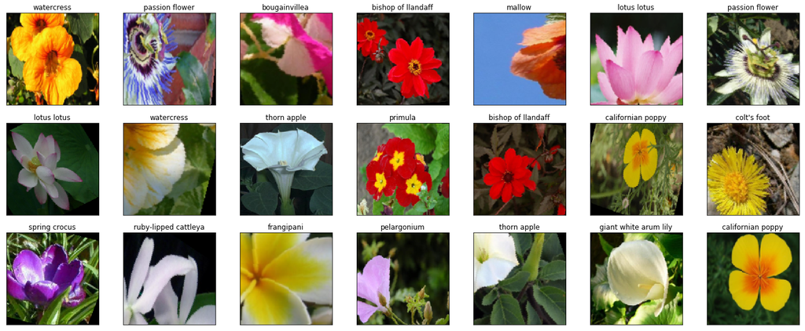

```python
# TODO: Build and train your network

# to get the class flower names to plot it
class_names = [cat_to_name[i] for i in train_data.classes]
# to get a batch of training data
inputs, classes = next(iter(dataloaders['training']))

# to plot a batch of preprocessed flower images
# choosing the size, rows, and columns
fig, axis = plt.subplots(figsize=(20, 8), nrows=3, ncols=7, tight_layout=True)
axis = axis.flatten()
k = 0
for ax, label in zip(axis, classes):
    image = inputs[k].to("cpu").clone().detach() # to colne the input tensor and put it in cpu
    image = image.numpy().squeeze() # to convert the tensor to numpy array and squeeze the first dimension of it
    image = image.transpose(1, 2, 0) # reshaping (height, width, channels)
    image = image * np.array((0.229, 0.224, 0.225)) + np.array((0.485, 0.456, 0.406)) # to keep the colors back again
    image = image.clip(0, 1) # to clip and limit the image values between 0 and 1

    # Displaying and showing the flower images
    ax.imshow(image)
    ax.set_title(class_names[label])
    ax.set_xticks([]); ax.set_yticks([])
    k+=1

print("These are some of wonderful flower breeds in our training dataset.")
```

```python
# to import and use vgg pretrained model architecture by using CNN
model = models.vgg16(pretrained=True)

# to change the output features number to the classes number
model.classifier[6] = nn.Linear(4096, len(cat_to_name))

# to freeze the training for all features(layers)
for param in model.features.parameters():
    param.requires_grad = False

# if CUDA is available, it'll move the model to GPU
if torch.cuda.is_available() :
    model = model.cuda()

print(model)
```

```
VGG(
  (features): Sequential(
    (0): Conv2d(3, 64, kernel_size=(3, 3), stride=(1, 1), padding=(1, 1))
    (1): ReLU(inplace=True)
    (2): Conv2d(64, 64, kernel_size=(3, 3), stride=(1, 1), padding=(1, 1))
    (3): ReLU(inplace=True)
    (4): MaxPool2d(kernel_size=2, stride=2, padding=0, dilation=1, ceil_mode=False)
    (5): Conv2d(64, 128, kernel_size=(3, 3), stride=(1, 1), padding=(1, 1))
    (6): ReLU(inplace=True)
    (7): Conv2d(128, 128, kernel_size=(3, 3), stride=(1, 1), padding=(1, 1))
    (8): ReLU(inplace=True)
    (9): MaxPool2d(kernel_size=2, stride=2, padding=0, dilation=1, ceil_mode=False)
    (10): Conv2d(128, 256, kernel_size=(3, 3), stride=(1, 1), padding=(1, 1))
    (11): ReLU(inplace=True)
    (12): Conv2d(256, 256, kernel_size=(3, 3), stride=(1, 1), padding=(1, 1))
    (13): ReLU(inplace=True)
    (14): Conv2d(256, 256, kernel_size=(3, 3), stride=(1, 1), padding=(1, 1))
    (15): ReLU(inplace=True)
    (16): MaxPool2d(kernel_size=2, stride=2, padding=0, dilation=1, ceil_mode=False)
    (17): Conv2d(256, 512, kernel_size=(3, 3), stride=(1, 1), padding=(1, 1))
    (18): ReLU(inplace=True)
    (19): Conv2d(512, 512, kernel_size=(3, 3), stride=(1, 1), padding=(1, 1))
    (20): ReLU(inplace=True)
    (21): Conv2d(512, 512, kernel_size=(3, 3), stride=(1, 1), padding=(1, 1))
    (22): ReLU(inplace=True)
    (23): MaxPool2d(kernel_size=2, stride=2, padding=0, dilation=1, ceil_mode=False)
    (24): Conv2d(512, 512, kernel_size=(3, 3), stride=(1, 1), padding=(1, 1))
    (25): ReLU(inplace=True)
    (26): Conv2d(512, 512, kernel_size=(3, 3), stride=(1, 1), padding=(1, 1))
    (27): ReLU(inplace=True)
    (28): Conv2d(512, 512, kernel_size=(3, 3), stride=(1, 1), padding=(1, 1))
    (29): ReLU(inplace=True)
    (30): MaxPool2d(kernel_size=2, stride=2, padding=0, dilation=1, ceil_mode=False)
  )
  (avgpool): AdaptiveAvgPool2d(output_size=(7, 7))
  (classifier): Sequential(
    (0): Linear(in_features=25088, out_features=4096, bias=True)
    (1): ReLU(inplace=True)
    (2): Dropout(p=0.5, inplace=False)
    (3): Linear(in_features=4096, out_features=4096, bias=True)
    (4): ReLU(inplace=True)
    (5): Dropout(p=0.5, inplace=False)
    (6): Linear(in_features=4096, out_features=102, bias=True)
  )
)
```

```python
for i in model.parameters():
    if i.requires_grad:
         print(i.name, i.data.shape)
```

```
None torch.Size([4096, 25088])
None torch.Size([4096])
None torch.Size([4096, 4096])
None torch.Size([4096])
None torch.Size([102, 4096])
None torch.Size([102])
```

```python
# calcaluting the images in training folders and put it in a dictionary
n_images_dic = dict()
for dir in os.listdir('flowers/train'):
    n_classes = dir
    img_count = len(os.listdir('flowers/train/' + dir))
    n_images_dic[int(n_classes)] = img_count
```

```python
# to transform the dictionary to pandas dataframe
num_train_classes = pd.DataFrame.from_dict(n_images_dic, orient='index').reset_index() # to reset index of a Data Frame, and
num_train_classes.columns = ['class', 'counts']                                        # set a list of int ranging from 0
num_train_classes = num_train_classes.sort_values('class').reset_index()               # to length of data as index.
num_train_classes.head()
```

|  | index | class | counts |
| --- | --- | --- | --- |
| 0 | 0 | 1 | 27 |
| 1 | 14 | 2 | 49 |
| 2 | 25 | 3 | 36 |
| 3 | 36 | 4 | 44 |
| 4 | 47 | 5 | 54 |

```python
# weight tensor for CrossEntropyLoss
# to reduce counts, transfrom it to float tensor and use it in CrossEntropyLoss
weight = torch.FloatTensor(1/num_train_classes['counts']).cuda()

lr = 0.01 # learning rate
epochs = 10 # number of epochs

criterion = nn.CrossEntropyLoss(weight=weight)
optimizer = optim.SGD(model.classifier.parameters(), lr= lr) # Adam is not fine here, but SGD is better

weight
```

```
tensor([0.0370, 0.0204, 0.0278, 0.0227, 0.0185, 0.0286, 0.0303, 0.0143, 0.0244,
        0.0263, 0.0147, 0.0137, 0.0263, 0.0227, 0.0263, 0.0278, 0.0167, 0.0154,
        0.0263, 0.0217, 0.0294, 0.0213, 0.0139, 0.0286, 0.0294, 0.0303, 0.0278,
        0.0182, 0.0161, 0.0164, 0.0208, 0.0278, 0.0323, 0.0357, 0.0303, 0.0161,
        0.0109, 0.0227, 0.0303, 0.0185, 0.0103, 0.0204, 0.0100, 0.0137, 0.0303,
        0.0064, 0.0164, 0.0175, 0.0263, 0.0137, 0.0049, 0.0149, 0.0143, 0.0213,
        0.0179, 0.0109, 0.0200, 0.0116, 0.0179, 0.0118, 0.0278, 0.0208, 0.0238,
        0.0238, 0.0114, 0.0196, 0.0278, 0.0233, 0.0217, 0.0196, 0.0156, 0.0130,
        0.0068, 0.0070, 0.0105, 0.0120, 0.0049, 0.0089, 0.0294, 0.0122, 0.0074,
        0.0122, 0.0096, 0.0152, 0.0208, 0.0208, 0.0196, 0.0086, 0.0065, 0.0152,
        0.0169, 0.0189, 0.0294, 0.0076, 0.0099, 0.0139, 0.0185, 0.0147, 0.0200,
        0.0286, 0.0204, 0.0278], device='cuda:0')
```

```python
# Training function
def train(n_epochs, loaders, model, optimizer, criterion, model_path, summary_path):
    '''
    to train our CNN model architecture vgg on flowers training dataset
    returns a trained model
    '''

    # creating a starting point (minimum validation loss) to decrease the valid_loss
    valid_loss_min = np.Inf

    # creating empty lists to monitor training and validation losses and accuracy for each epoch
    train_loss_list = []
    train_acc_list = []

    valid_loss_list = []
    valid_acc_list = []

    # start time to calculate the time for training process
    train_start = time()
    for epoch in range(1, n_epochs+1):
        with tqdm(total = len(train_data)) as train_epoch:
            train_epoch.set_description(f'Epoch {epoch}/{n_epochs}')
            epoch_start = time()

            # initialize variables to monitor training and validation loss
            # creating varibles with float 0 values to add on it training and validation loss
            train_loss = 0.0
            train_correct = 0.0
            train_total = 0.0

            valid_loss = 0.0
            valid_correct = 0.0
            valid_total = 0.0
            #=======================#
            #====train our model====#
            #=======================#
            model.train()
            for idx, (data, target) in enumerate(loaders['training']):
                # to move it to GPU
                X = data.to(device)
                y = target.to(device)

                # finding the loss and update the model parameters correctly and accordingly
                # Set and clear the gradients of all optimized variables to zero
                optimizer.zero_grad()
                # forward pass
                output = model(X)
                # calculate the batch loss by using CrossEntropyLoss
                loss = criterion(output, y)
                # backward pass
                loss.backward()
                # to perform a single optimization step to update model parameters
                optimizer.step()

                # update the training loss by this sample equation
                train_loss = train_loss + ((1 / (idx + 1)) * (loss.data - train_loss))

                # to convert output probabilities to predicted class
                _, pred = torch.max(output.data, 1)

                # comparing predictions with the true label
                train_correct += np.sum(np.squeeze(pred.eq(y.data.view_as(pred))).cpu().numpy())
                train_total += X.size(0)

                # Update the tqdm progress bar with Train loss and accuracy
                desc = f'Epoch: {epoch}/{n_epochs} - Train loss = {train_loss:.4f} - Train Accuracy = {train_correct/train_total:.2%}'
                train_epoch.set_description(desc)
                train_epoch.update(X.shape[0])
            #========================#
            #===validate our model===#
            #========================#
            model.eval()
        with tqdm(total = len(valid_data)) as valid_epoch:
            valid_epoch.set_description(f'Epoch {epoch}/{n_epochs}')
            for idx, (data, target) in enumerate(loaders['validation']):
                X = data.to(device)
                y = target.to(device)

                # Updating the rate of validation loss
                # forward pass
                output = model(X)
                # calculate the batch loss
                loss = criterion(output, y)

                # update the average of validation loss by using this equation
                valid_loss = valid_loss + ((1 / (idx + 1)) * (loss.data - valid_loss))

                # to convert output probabilities to predicted class
                _, pred = torch.max(output.data, 1)

                # comparing predictions with the true label
                valid_correct += np.sum(np.squeeze(pred.eq(y.data.view_as(pred))).cpu().numpy())
                valid_total += X.size(0)

                # Updating the progress bar with valid loss and accuracy
                desc = f'Epoch: {epoch}/{n_epochs} - Valid loss = {valid_loss:.4f} - Valid Accuracy = {valid_correct/(valid_total+1e-10):.2%}'
                valid_epoch.set_description(desc)
                valid_epoch.update(X.shape[0])


        # to append the train and valid loss for each epoch to the train_loss_list and valid_loss_list
        train_loss_list.append(train_loss.cpu().numpy())
        valid_loss_list.append(valid_loss.cpu().numpy())
        train_acc_list.append(100. * train_correct / train_total)
        valid_acc_list.append(100. * valid_correct / valid_total)

        ## if validation loss has decreased, it'll save the model
        if valid_loss <= valid_loss_min:
            print(f'Validation loss decreased ({valid_loss_min:.6f} --> {valid_loss:.6f}).  Saving the model ...')
            torch.save(model.state_dict(), model_path)
            valid_loss_min = valid_loss

    # Save Model Summary to a pandas DataFrame and convert it to csv file
    print('Done: saving the model summary in DataFrame...')
    summary_dic = {
        'epoch': np.arange(1, n_epochs+1, 1),
        'train_losses': train_loss_list,
        'train_acc': train_acc_list,
        'valid_losses': valid_loss_list,
        'valid_acc': valid_acc_list,
    }
    model_summary = pd.DataFrame(summary_dic)

    # convert from the DF to csv file
    model_summary.to_csv(summary_path, index=False)

    train_end = time()
    print(f'Training total elapsed time: {train_end-train_start:.0f} Seconds')
    return model, model_summary
```

```python
model, model_summary = train(epochs, dataloaders, model, optimizer,
                             criterion, 'saved_models/model.pt', 'saved_models/model_summary.csv')
```

```
Epoch: 1/10 - Train loss = 3.1805 - Train Accuracy = 25.69%: 100%|█████████████████| 6552/6552 [02:12<00:00, 49.44it/s]
Epoch: 1/10 - Valid loss = 1.7025 - Valid Accuracy = 54.65%: 100%|███████████████████| 818/818 [00:15<00:00, 53.44it/s]
```

```
Validation loss decreased (inf --> 1.702528).  Saving the model ...
```

```
Epoch: 2/10 - Train loss = 1.7740 - Train Accuracy = 50.46%: 100%|█████████████████| 6552/6552 [02:14<00:00, 48.88it/s]
Epoch: 2/10 - Valid loss = 1.1538 - Valid Accuracy = 65.77%: 100%|███████████████████| 818/818 [00:15<00:00, 52.82it/s]
```

```
Validation loss decreased (1.702528 --> 1.153753).  Saving the model ...
```

```
Epoch: 3/10 - Train loss = 1.4098 - Train Accuracy = 58.82%: 100%|█████████████████| 6552/6552 [02:14<00:00, 48.83it/s]
Epoch: 3/10 - Valid loss = 0.8603 - Valid Accuracy = 73.35%: 100%|███████████████████| 818/818 [00:15<00:00, 52.62it/s]
```

```
Validation loss decreased (1.153753 --> 0.860259).  Saving the model ...
```

```
Epoch: 4/10 - Train loss = 1.2413 - Train Accuracy = 63.05%: 100%|█████████████████| 6552/6552 [02:15<00:00, 48.35it/s]
Epoch: 4/10 - Valid loss = 0.8324 - Valid Accuracy = 74.21%: 100%|███████████████████| 818/818 [00:15<00:00, 53.23it/s]
```

```
Validation loss decreased (0.860259 --> 0.832393).  Saving the model ...
```

```
Epoch: 5/10 - Train loss = 1.1267 - Train Accuracy = 66.73%: 100%|█████████████████| 6552/6552 [02:15<00:00, 48.35it/s]
Epoch: 5/10 - Valid loss = 0.6467 - Valid Accuracy = 81.05%: 100%|███████████████████| 818/818 [00:15<00:00, 52.93it/s]
```

```
Validation loss decreased (0.832393 --> 0.646702).  Saving the model ...
```

```
Epoch: 6/10 - Train loss = 1.0607 - Train Accuracy = 67.67%: 100%|█████████████████| 6552/6552 [02:18<00:00, 47.34it/s]
Epoch: 6/10 - Valid loss = 0.5576 - Valid Accuracy = 82.76%: 100%|███████████████████| 818/818 [00:15<00:00, 52.35it/s]
```

```
Validation loss decreased (0.646702 --> 0.557573).  Saving the model ...
```

```
Epoch: 7/10 - Train loss = 0.9428 - Train Accuracy = 71.14%: 100%|█████████████████| 6552/6552 [02:18<00:00, 47.15it/s]
Epoch: 7/10 - Valid loss = 0.5992 - Valid Accuracy = 81.66%: 100%|███████████████████| 818/818 [00:15<00:00, 52.82it/s]
Epoch: 8/10 - Train loss = 0.9217 - Train Accuracy = 71.61%: 100%|█████████████████| 6552/6552 [02:16<00:00, 47.97it/s]
Epoch: 8/10 - Valid loss = 0.5470 - Valid Accuracy = 84.23%: 100%|███████████████████| 818/818 [00:15<00:00, 52.97it/s]
```

```
Validation loss decreased (0.557573 --> 0.546991).  Saving the model ...
```

```
Epoch: 9/10 - Train loss = 0.8518 - Train Accuracy = 73.96%: 100%|█████████████████| 6552/6552 [02:17<00:00, 47.74it/s]
Epoch: 9/10 - Valid loss = 0.5430 - Valid Accuracy = 83.13%: 100%|███████████████████| 818/818 [00:15<00:00, 52.46it/s]
```

```
Validation loss decreased (0.546991 --> 0.542980).  Saving the model ...
```

```
Epoch: 10/10 - Train loss = 0.8263 - Train Accuracy = 75.26%: 100%|████████████████| 6552/6552 [02:15<00:00, 48.36it/s]
Epoch: 10/10 - Valid loss = 0.4950 - Valid Accuracy = 86.19%: 100%|██████████████████| 818/818 [00:15<00:00, 51.70it/s]
```

```
Validation loss decreased (0.542980 --> 0.494971).  Saving the model ...
Done: saving the model summary in DataFrame...
Training total elapsed time: 1543 Seconds
```

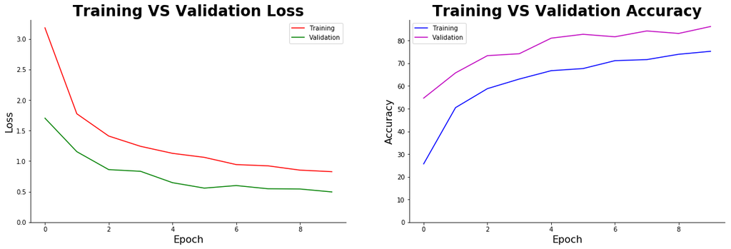

```python
# Plotting the model summary
def plot_model_summary(model_summary):
    fig, ax = plt.subplots(figsize=(20, 6), ncols=2)
    ax[0].plot(model_summary.train_losses, color='r')
    ax[0].plot(model_summary.valid_losses, color='g')
    ax[0].spines['right'].set_visible(False) # to remove the axis that we don't need
    ax[0].spines['top'].set_visible(False)
    ax[0].set_ylabel('Loss', fontdict={'fontsize': 16})
    ax[0].set_xlabel('Epoch', fontdict={'fontsize': 16})
    ax[0].set_title('Training VS Validation Loss', fontdict={'fontsize': 24, 'fontweight':'bold'})
    ax[0].set_ylim(0)
    ax[0].legend(['Training', 'Validation']);
    ax[1].plot(model_summary.train_acc, color='b')
    ax[1].plot(model_summary.valid_acc, color='m')
    ax[1].spines['right'].set_visible(False)
    ax[1].spines['top'].set_visible(False)
    ax[1].set_ylabel('Accuracy', fontdict={'fontsize': 16})
    ax[1].set_xlabel('Epoch', fontdict={'fontsize': 16})
    ax[1].set_title('Training VS Validation Accuracy', fontdict={'fontsize': 24, 'fontweight':'bold'})
    ax[1].set_ylim(0)
    ax[1].legend(['Training', 'Validation'])
    plt.show()

plot_model_summary(pd.read_csv('saved_models/model_summary.csv'))
```

## Testing your network

It's good practice to test your trained network on test data, images the network has never seen either in training or validation. This will give you a good estimate for the model's performance on completely new images. Run the test images through the network and measure the accuracy, the same way you did validation. You should be able to reach around 70% accuracy on the test set if the model has been trained well.

```python
# TODO: Do validation on the test set

def perform_testing():
    loss_fn = nn.NLLLoss()
    model.eval()

    total = 0
    accuracy = 0
    test_loss = 0
    total_images = len(dataloaders["testing"].batch_sampler) * dataloaders["testing"].batch_size
    for ii, (images, labels) in enumerate(dataloaders['testing']):
        X = images.to(device)
        y = labels.to(device)

        output = model.forward(X)
#         loss_fn = nn.NLLLoss()
#         test_loss += loss_fn(output, y).data[0]

        loss = criterion(output, y)
        test_loss = test_loss + ((1 / (ii + 1)) * (loss.data - test_loss))

        # Calculating the accuracy
        _, predicted = torch.max(output.data, 1)
        accuracy += (predicted == y).sum().item()
        total += X.size(0)

    print('Batch: {} '.format(ii+1),
          '\nTest Loss: {:.3f}.. '.format(test_loss/len(dataloaders['testing'])),
          f'\nAccurately classified with {(100 * accuracy // total):d}% of {total_images} images.')

perform_testing()
```

```
Batch: 26
Test Loss: 0.025..
Accurately classified with 82% of 832 images.
```

## Save the checkpoint

Now that your network is trained, save the model so you can load it later for making predictions. You probably want to save other things such as the mapping of classes to indices which you get from one of the image datasets: `image_datasets['train'].class_to_idx`. You can attach this to the model as an attribute which makes inference easier later on.

`model.class_to_idx = image_datasets['train'].class_to_idx`

Remember that you'll want to completely rebuild the model later so you can use it for inference. Make sure to include any information you need in the checkpoint. If you want to load the model and keep training, you'll want to save the number of epochs as well as the optimizer state, `optimizer.state_dict`. You'll likely want to use this trained model in the next part of the project, so best to save it now.

```python
# TODO: Save the checkpoint

model.class_to_idx = image_datasets['training'].class_to_idx
checkpoint = {'input_size': [3, 224, 224],
              'batch_size': dataloaders['training'].batch_size,
              'output_size': 102,
              'state_dic': model.state_dict(),
              'optimizer_dic':optimizer.state_dict(),
              'class_to_idx': model.class_to_idx,
              'classifier': model.classifier,
              'classes_weights': weight}
torch.save(checkpoint, 'saved_models/checkpoint.pth')
```

## Loading the checkpoint

At this point it's good to write a function that can load a checkpoint and rebuild the model. That way you can come back to this project and keep working on it without having to retrain the network.

**While training on GPU, loading weights for CPU model:**

- check: [CPU and GPU in pytorch](https://discuss.pytorch.org/t/loading-weights-for-cpu-model-while-trained-on-gpu/1032)

```python
# TODO: Write a function that loads a checkpoint and rebuilds the model

def load_checkpoint(file='saved_models/checkpoint.pth'):
    model_state = torch.load(file, map_location=lambda storage, loc: storage)


    model = models.vgg16(pretrained=True)
    model.classifier = model_state['classifier']
    model.load_state_dict(model_state['state_dic'])
    model.class_to_idx = model_state['class_to_idx']

    return model

checkpoint_model = load_checkpoint()
```

# Inference for classification

Now you'll write a function to use a trained network for inference. That is, you'll pass an image into the network and predict the class of the flower in the image. Write a function called `predict` that takes an image and a model, then returns the top $K$ most likely classes along with the probabilities. It should look like

```
probs, classes = predict(image_path, model)
print(probs)
print(classes)
> [ 0.01558163  0.01541934  0.01452626  0.01443549  0.01407339]
> ['70', '3', '45', '62', '55']
```

First you'll need to handle processing the input image such that it can be used in your network.

## Image Preprocessing

You'll want to use `PIL` to load the image ([documentation](https://pillow.readthedocs.io/en/latest/reference/Image.html)). It's best to write a function that preprocesses the image so it can be used as input for the model. This function should process the images in the same manner used for training.

First, resize the images where the shortest side is 256 pixels, keeping the aspect ratio. This can be done with the [`thumbnail`](http://pillow.readthedocs.io/en/3.1.x/reference/Image.html#PIL.Image.Image.thumbnail) or [`resize`](http://pillow.readthedocs.io/en/3.1.x/reference/Image.html#PIL.Image.Image.thumbnail) methods. Then you'll need to crop out the center 224x224 portion of the image.

Color channels of images are typically encoded as integers 0-255, but the model expected floats 0-1. You'll need to convert the values. It's easiest with a Numpy array, which you can get from a PIL image like so `np_image = np.array(pil_image)`.

As before, the network expects the images to be normalized in a specific way. For the means, it's `[0.485, 0.456, 0.406]` and for the standard deviations `[0.229, 0.224, 0.225]`. You'll want to subtract the means from each color channel, then divide by the standard deviation.

And finally, PyTorch expects the color channel to be the first dimension but it's the third dimension in the PIL image and Numpy array. You can reorder dimensions using [`ndarray.transpose`](https://docs.scipy.org/doc/numpy-1.13.0/reference/generated/numpy.ndarray.transpose.html). The color channel needs to be first and retain the order of the other two dimensions.

```python
def process_image(image):
    ''' Scales, crops, and normalizes a PIL image for a PyTorch model,
        returns an Numpy array
    '''
    pil_image = Image.open(image).convert("RGB")
    normalizer = transforms.Normalize(mean = [0.485, 0.456, 0.406],
                                      std = [0.229, 0.224, 0.225])

    in_transforms = transforms.Compose([transforms.Resize(256),
                                        transforms.CenterCrop(224),
                                        transforms.ToTensor(),
                                        normalizer])
    pil_image = in_transforms(pil_image)

    return pil_image

# TODO: Process a PIL image for use in a PyTorch model
check_image = process_image(valid_dir + '/55/image_04696.jpg')
type(check_image)
```

```
torch.Tensor
```

To check your work, the function below converts a PyTorch tensor and displays it in the notebook. If your `process_image` function works, running the output through this function should return the original image (except for the cropped out portions).

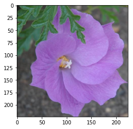

```python
def imshow(image, ax=None, title=None):
    """Imshow for Tensor."""
    if ax is None:
        fig, ax = plt.subplots()

    # PyTorch tensors assume the color channel is the first dimension
    # but matplotlib assumes is the third dimension
    image = image.numpy().transpose((1, 2, 0))

    # Undo preprocessing
    mean = np.array([0.485, 0.456, 0.406])
    std = np.array([0.229, 0.224, 0.225])
    image = std * image + mean

    # Image needs to be clipped between 0 and 1 or it looks like noise when displayed
    image = np.clip(image, 0, 1)

    ax.imshow(image)

    return ax

imshow(check_image)
```

## Class Prediction

Once you can get images in the correct format, it's time to write a function for making predictions with your model. A common practice is to predict the top 5 or so (usually called top-$K$) most probable classes. You'll want to calculate the class probabilities then find the $K$ largest values.

To get the top $K$ largest values in a tensor use [`x.topk(k)`](http://pytorch.org/docs/master/torch.html#torch.topk). This method returns both the highest `k` probabilities and the indices of those probabilities corresponding to the classes. You need to convert from these indices to the actual class labels using `class_to_idx` which hopefully you added to the model or from an `ImageFolder` you used to load the data (see here). Make sure to invert the dictionary so you get a mapping from index to class as well.

Again, this method should take a path to an image and a model checkpoint, then return the probabilities and classes.

```
probs, classes = predict(image_path, model)
print(probs)
print(classes)
> [ 0.01558163  0.01541934  0.01452626  0.01443549  0.01407339]
> ['70', '3', '45', '62', '55']
```

```python
def predict(image_file, model, topk=5):
    ''' Predict the class (or classes) of an image using a trained deep learning model.
    '''

    # TODO: Implement the code to predict the class from an image file

    model.cpu()

    # evaluation mode
    # check: https://pytorch.org/docs/stable/nn.html#torch.nn.Module.eval
    model.eval()

    # loading image as a torch Tensor
    image = process_image(image_file)

    # Unsqueeze returns a new tensor with a dimension of size one
    # check: https://pytorch.org/docs/stable/torch.html#torch.unsqueeze
    image = image.unsqueeze(0)

    # Stopping gradient calculation
    with torch.no_grad():
        output = model.forward(image)
        top_probability, top_labels = torch.topk(output, topk)

        # Calculating the exponential values
        top_probability  = top_probability.exp()

    idx_to_class = {model.class_to_idx[k]: k for k in model.class_to_idx}
    classes = [idx_to_class[i] for i in top_labels.numpy()[0]]

    return top_probability.numpy()[0], classes
```

## Sanity Checking

Now that you can use a trained model for predictions, check to make sure it makes sense. Even if the testing accuracy is high, it's always good to check that there aren't obvious bugs. Use `matplotlib` to plot the probabilities for the top 5 classes as a bar graph, along with the input image. It should look like this:

[figure not shown]

You can convert from the class integer encoding to actual flower names with the `cat_to_name.json` file (should have been loaded earlier in the notebook). To show a PyTorch tensor as an image, use the `imshow` function defined above.

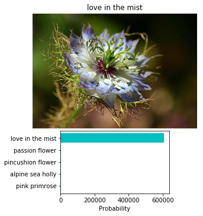

```
Correct Classification: love in the mist
Correct Prediction: True
```

```python
# TODO: Display an image along with the top 5 classes

check_image_file = valid_dir + '/33/image_06455.jpg'
correct_class = cat_to_name['33']

top_probability, top_classes = predict(check_image_file, checkpoint_model, 5)

label = top_classes[0]

fig = plt.figure(figsize=(6,6))
sc_img = plt.subplot2grid((15,9), (0,0), colspan=9, rowspan=9)
sc_pred = plt.subplot2grid((15,9), (9,2), colspan=5, rowspan=5)

image = Image.open(check_image_file)
sc_img.axis('off')
sc_img.set_title(f'{cat_to_name[label]}')
sc_img.imshow(image)

labels = []
for idx in top_classes:
    labels.append(cat_to_name[idx])

yp = np.arange(5)
sc_pred.set_yticks(yp)
sc_pred.set_yticklabels(labels)
sc_pred.set_xlabel('Probability')
sc_pred.invert_yaxis()
sc_pred.barh(yp, top_probability, xerr=0, align='center', color='c')

plt.show()

print(f'Correct Classification: {correct_class}')
print(f'Correct Prediction: {correct_class == cat_to_name[label]}')
```

## Another way to check the prediction by plotting

```python
test_images_path = np.array(glob("flowers/test/*/*"))
random_images = np.random.randint(0, test_images_path.shape[0], (5))
test_images = test_images_path[random_images]
test_labels = [test_images[x].split('\\')[1] for x in range(test_images.shape[0])]
print(test_images)
print(test_labels)
```

```
['flowers/test\\11\\image_03177.jpg' 'flowers/test\\29\\image_04095.jpg'
 'flowers/test\\53\\image_03714.jpg' 'flowers/test\\83\\image_01755.jpg'
 'flowers/test\\46\\image_01078.jpg']
['11', '29', '53', '83', '46']
```

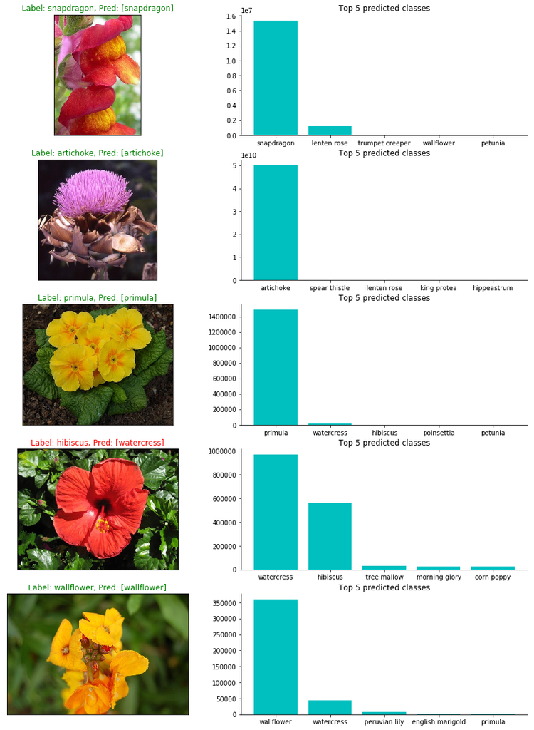

```python
def plot_predictions(images, labels, model, topk):
    """
    it plots the predictions and the top k(5) predicted classes.
    param:
    images: test images to plot
    labels: true labels
    model: the model to use for predictions
    topk: the number of top predicted classes to return
    """
    # Displaying the images and the barchart with the predictions probabilty
    fig, axes = plt.subplots(images.shape[0], 2, figsize=(16, 20))
    fig.subplots_adjust(hspace=0.2, wspace=0)

    for i, (image, label) in enumerate(zip(images, labels)):
        probabilty, predicted_labels = predict(image, model, 5)
        predicted_label = predicted_labels[np.argmax(probabilty)]
        image_title = f"Label: {cat_to_name[label]}, Pred: [{cat_to_name[predicted_label]}]"
        axes[i, 0].imshow(Image.open(image))
        axes[i, 0].get_xaxis().set_visible(False)
        axes[i, 0].get_yaxis().set_visible(False)
        if label == predicted_label:
            axes[i, 0].set_title(image_title, color='g') # true and correct prediction
        else:
            axes[i, 0].set_title(image_title, color='r') # false and incorrect prediction
        predicted_classes = [cat_to_name[i] for i in predicted_labels]
        axes[i, 1].bar(predicted_classes, probabilty, color='c')
        axes[i, 1].set_title(f"Top {topk} predicted classes")
        axes[i, 1].spines['top'].set_visible(False)   # to delete the useless axis
        axes[i, 1].spines['right'].set_visible(False) # to delete the useless axis

    plt.show()

plot_predictions(test_images, test_labels, model, 5)
```